# Part I - Prosper Loan Data Exploration

## Introduction

This project explores the Proper loan dataset, which is America’s first marketplace lending platform, with over $9 billion in funded loans. This data set contains 113,937 loans with 81 variables on each loan, including loan amount, borrower rate (or interest rate), current loan status, borrower income, borrower employment status, borrower credit history, and the latest payment information.

The project goes further to summarize the characteristics of variables that can affect the loan status and to get some ideas about the relationships among multiple variables using summary statistics and data visualizations.

## Preliminary Wrangling

```python
!pip install -U seaborn
```

```python
# import all packages and set plots to be embedded inline
import numpy as np
import pandas as pd
import matplotlib.pyplot as plt
import seaborn as sb

%matplotlib inline
```

Load the dataset into the workspace

```python
loan_data = pd.read_csv('prosper-loan.csv')
```

View the first 5 rows of the data

```python
loan_data.head()
```

|  | ListingKey | ListingNumber | ListingCreationDate | CreditGrade | Term | LoanStatus | ClosedDate | BorrowerAPR | BorrowerRate | LenderYield | ... | LP_ServiceFees | LP_CollectionFees | LP_GrossPrincipalLoss | LP_NetPrincipalLoss | LP_NonPrincipalRecoverypayments | PercentFunded | Recommendations | InvestmentFromFriendsCount | InvestmentFromFriendsAmount | Investors |
| --- | --- | --- | --- | --- | --- | --- | --- | --- | --- | --- | --- | --- | --- | --- | --- | --- | --- | --- | --- | --- | --- |
| 0 | 1021339766868145413AB3B | 193129 | 2007-08-26 19:09:29.263000000 | C | 36 | Completed | 2009-08-14 00:00:00 | 0.16516 | 0.1580 | 0.1380 | ... | -133.18 | 0.0 | 0.0 | 0.0 | 0.0 | 1.0 | 0 | 0 | 0.0 | 258 |
| 1 | 10273602499503308B223C1 | 1209647 | 2014-02-27 08:28:07.900000000 | NaN | 36 | Current | NaN | 0.12016 | 0.0920 | 0.0820 | ... | 0.00 | 0.0 | 0.0 | 0.0 | 0.0 | 1.0 | 0 | 0 | 0.0 | 1 |
| 2 | 0EE9337825851032864889A | 81716 | 2007-01-05 15:00:47.090000000 | HR | 36 | Completed | 2009-12-17 00:00:00 | 0.28269 | 0.2750 | 0.2400 | ... | -24.20 | 0.0 | 0.0 | 0.0 | 0.0 | 1.0 | 0 | 0 | 0.0 | 41 |
| 3 | 0EF5356002482715299901A | 658116 | 2012-10-22 11:02:35.010000000 | NaN | 36 | Current | NaN | 0.12528 | 0.0974 | 0.0874 | ... | -108.01 | 0.0 | 0.0 | 0.0 | 0.0 | 1.0 | 0 | 0 | 0.0 | 158 |
| 4 | 0F023589499656230C5E3E2 | 909464 | 2013-09-14 18:38:39.097000000 | NaN | 36 | Current | NaN | 0.24614 | 0.2085 | 0.1985 | ... | -60.27 | 0.0 | 0.0 | 0.0 | 0.0 | 1.0 | 0 | 0 | 0.0 | 20 |

5 rows × 81 columns

How many rows and columns are in the dataset

```python
loan_data.shape
```

```
(113937, 81)
```

Get more information about the dataset and the data types of each column

```python
loan_data.info()
```

```
<class 'pandas.core.frame.DataFrame'>
RangeIndex: 113937 entries, 0 to 113936
Data columns (total 81 columns):
ListingKey                             113937 non-null object
ListingNumber                          113937 non-null int64
ListingCreationDate                    113937 non-null object
CreditGrade                            28953 non-null object
Term                                   113937 non-null int64
LoanStatus                             113937 non-null object
ClosedDate                             55089 non-null object
BorrowerAPR                            113912 non-null float64
BorrowerRate                           113937 non-null float64
LenderYield                            113937 non-null float64
EstimatedEffectiveYield                84853 non-null float64
EstimatedLoss                          84853 non-null float64
EstimatedReturn                        84853 non-null float64
ProsperRating (numeric)                84853 non-null float64
ProsperRating (Alpha)                  84853 non-null object
ProsperScore                           84853 non-null float64
ListingCategory (numeric)              113937 non-null int64
BorrowerState                          108422 non-null object
Occupation                             110349 non-null object
EmploymentStatus                       111682 non-null object
EmploymentStatusDuration               106312 non-null float64
IsBorrowerHomeowner                    113937 non-null bool
CurrentlyInGroup                       113937 non-null bool
GroupKey                               13341 non-null object
DateCreditPulled                       113937 non-null object
CreditScoreRangeLower                  113346 non-null float64
CreditScoreRangeUpper                  113346 non-null float64
FirstRecordedCreditLine                113240 non-null object
CurrentCreditLines                     106333 non-null float64
OpenCreditLines                        106333 non-null float64
TotalCreditLinespast7years             113240 non-null float64
OpenRevolvingAccounts                  113937 non-null int64
OpenRevolvingMonthlyPayment            113937 non-null float64
InquiriesLast6Months                   113240 non-null float64
TotalInquiries                         112778 non-null float64
CurrentDelinquencies                   113240 non-null float64
AmountDelinquent                       106315 non-null float64
```

[output cut: 31 more lines]

```
LP_CustomerPayments                    113937 non-null float64
LP_CustomerPrincipalPayments           113937 non-null float64
LP_InterestandFees                     113937 non-null float64
LP_ServiceFees                         113937 non-null float64
LP_CollectionFees                      113937 non-null float64
LP_GrossPrincipalLoss                  113937 non-null float64
LP_NetPrincipalLoss                    113937 non-null float64
LP_NonPrincipalRecoverypayments        113937 non-null float64
PercentFunded                          113937 non-null float64
Recommendations                        113937 non-null int64
InvestmentFromFriendsCount             113937 non-null int64
InvestmentFromFriendsAmount            113937 non-null float64
Investors                              113937 non-null int64
dtypes: bool(3), float64(50), int64(11), object(17)
memory usage: 68.1+ MB
```

The analysis will only include 13 columns so I will create a new dataframe that will contain only these features.

```python
data = loan_data[[
    'ListingKey',
    'LoanOriginalAmount',
    'Term',
    'BorrowerAPR',
    'BorrowerRate',
    'ProsperRating (Alpha)',
    'EstimatedReturn',
    'MonthlyLoanPayment',
    'EmploymentStatus',
    'IncomeRange',
    'StatedMonthlyIncome',
    'LoanStatus',
    'ListingCategory (numeric)'
    ]].copy()
```

For better reading and understanding , the ProsperRating (Aplha) and ListingCategory (Numeric) columns will be renamed to ProsperRating and ListingCategory respectively.

```python
# rename some columns
data.rename(columns = {'ProsperRating (Alpha)': 'ProsperRating','ListingCategory (numeric)': 'ListingCategory'},inplace = True)
```

Inspect the first 5 rows of the dataset

```python
data.head()
```

|  | ListingKey | LoanOriginalAmount | Term | BorrowerAPR | BorrowerRate | ProsperRating | EstimatedReturn | MonthlyLoanPayment | EmploymentStatus | IncomeRange | StatedMonthlyIncome | LoanStatus | ListingCategory |
| --- | --- | --- | --- | --- | --- | --- | --- | --- | --- | --- | --- | --- | --- |
| 0 | 1021339766868145413AB3B | 9425 | 36 | 0.16516 | 0.1580 | NaN | NaN | 330.43 | Self-employed | $25,000-49,999 | 3083.333333 | Completed | 0 |
| 1 | 10273602499503308B223C1 | 10000 | 36 | 0.12016 | 0.0920 | A | 0.05470 | 318.93 | Employed | $50,000-74,999 | 6125.000000 | Current | 2 |
| 2 | 0EE9337825851032864889A | 3001 | 36 | 0.28269 | 0.2750 | NaN | NaN | 123.32 | Not available | Not displayed | 2083.333333 | Completed | 0 |
| 3 | 0EF5356002482715299901A | 10000 | 36 | 0.12528 | 0.0974 | A | 0.06000 | 321.45 | Employed | $25,000-49,999 | 2875.000000 | Current | 16 |
| 4 | 0F023589499656230C5E3E2 | 15000 | 36 | 0.24614 | 0.2085 | D | 0.09066 | 563.97 | Employed | $100,000+ | 9583.333333 | Current | 2 |

Inspect the last 5 rows of the dataset

```python
data.tail()
```

|  | ListingKey | LoanOriginalAmount | Term | BorrowerAPR | BorrowerRate | ProsperRating | EstimatedReturn | MonthlyLoanPayment | EmploymentStatus | IncomeRange | StatedMonthlyIncome | LoanStatus | ListingCategory |
| --- | --- | --- | --- | --- | --- | --- | --- | --- | --- | --- | --- | --- | --- |
| 113932 | E6D9357655724827169606C | 10000 | 36 | 0.22354 | 0.1864 | C | 0.09500 | 364.74 | Employed | $50,000-74,999 | 4333.333333 | Current | 1 |
| 113933 | E6DB353036033497292EE43 | 2000 | 36 | 0.13220 | 0.1110 | A | 0.08070 | 65.57 | Employed | $75,000-99,999 | 8041.666667 | FinalPaymentInProgress | 7 |
| 113934 | E6E13596170052029692BB1 | 10000 | 60 | 0.23984 | 0.2150 | D | 0.08578 | 273.35 | Employed | $25,000-49,999 | 2875.000000 | Current | 1 |
| 113935 | E6EB3531504622671970D9E | 15000 | 60 | 0.28408 | 0.2605 | C | 0.15950 | 449.55 | Full-time | $25,000-49,999 | 3875.000000 | Completed | 2 |
| 113936 | E6ED3600409833199F711B7 | 2000 | 36 | 0.13189 | 0.1039 | A | 0.06081 | 64.90 | Employed | $50,000-74,999 | 4583.333333 | Current | 1 |

Get more information about the data type of each feature

```python
data.dtypes
```

```
ListingKey              object
LoanOriginalAmount       int64
Term                     int64
BorrowerAPR            float64
BorrowerRate           float64
ProsperRating           object
EstimatedReturn        float64
MonthlyLoanPayment     float64
EmploymentStatus        object
IncomeRange             object
StatedMonthlyIncome    float64
LoanStatus              object
ListingCategory          int64
dtype: object
```

```python
data.shape
```

```
(113937, 13)
```

The dataset is now made up of 13 features and 113937 observations

Summary Statistics of the numeric and floats variables

```python
data.describe()
```

|  | LoanOriginalAmount | Term | BorrowerAPR | BorrowerRate | EstimatedReturn | MonthlyLoanPayment | StatedMonthlyIncome | ListingCategory |
| --- | --- | --- | --- | --- | --- | --- | --- | --- |
| count | 113937.00000 | 113937.000000 | 113912.000000 | 113937.000000 | 84853.000000 | 113937.000000 | 1.139370e+05 | 113937.000000 |
| mean | 8337.01385 | 40.830248 | 0.218828 | 0.192764 | 0.096068 | 272.475783 | 5.608026e+03 | 2.774209 |
| std | 6245.80058 | 10.436212 | 0.080364 | 0.074818 | 0.030403 | 192.697812 | 7.478497e+03 | 3.996797 |
| min | 1000.00000 | 12.000000 | 0.006530 | 0.000000 | -0.182700 | 0.000000 | 0.000000e+00 | 0.000000 |
| 25% | 4000.00000 | 36.000000 | 0.156290 | 0.134000 | 0.074080 | 131.620000 | 3.200333e+03 | 1.000000 |
| 50% | 6500.00000 | 36.000000 | 0.209760 | 0.184000 | 0.091700 | 217.740000 | 4.666667e+03 | 1.000000 |
| 75% | 12000.00000 | 36.000000 | 0.283810 | 0.250000 | 0.116600 | 371.580000 | 6.825000e+03 | 3.000000 |
| max | 35000.00000 | 60.000000 | 0.512290 | 0.497500 | 0.283700 | 2251.510000 | 1.750003e+06 | 20.000000 |

Distinct value counts of the term of the loan

```python
data['Term'].value_counts()
```

```
36    87778
60    24545
12     1614
Name: Term, dtype: int64
```

Distinct value counts of the loan status

```python
data['LoanStatus'].value_counts()
```

```
Current                   56576
Completed                 38074
Chargedoff                11992
Defaulted                  5018
Past Due (1-15 days)        806
Past Due (31-60 days)       363
Past Due (61-90 days)       313
Past Due (91-120 days)      304
Past Due (16-30 days)       265
FinalPaymentInProgress      205
Past Due (>120 days)         16
Cancelled                     5
Name: LoanStatus, dtype: int64
```

Distinct value counts of the prosper rating

```python
data['ProsperRating'].value_counts()
```

```
C     18345
B     15581
A     14551
D     14274
E      9795
HR     6935
AA     5372
Name: ProsperRating, dtype: int64
```

Distinct value counts of the Employment Status

```python
data['EmploymentStatus'].value_counts()
```

```
Employed         67322
Full-time        26355
Self-employed     6134
Not available     5347
Other             3806
Part-time         1088
Not employed       835
Retired            795
Name: EmploymentStatus, dtype: int64
```

Since the loan term, loan status, employment status and the prosper rating have finite values, These columns will be converted to categorical variables for proper visualization and analysis.

```python
# Therefore a for in loop will be to aid this conversion

var_dict = {
    'LoanStatus': [
        'Current',
        'Completed',
        'Chargedoff',
        'Defaulted',
        'Past Due (1-15 days)',
        'Past Due (31-60 days)',
        'Past Due (61-90 days)',
        'Past Due (91-120 days)',
        'Past Due (16-30 days)',
        'FinalPaymentInProgress',
        'Past Due (>120 days)',
        'Cancelled'
    ],
    'Term': [
        36,
        60,
        12
    ],
    'EmploymentStatus': [
        'Employed',
        'Full-time',
        'Self-employed',
        'Not available',
        'Other',
        'Part-time',
        'Not employed',
        'Retired'
    ],
    'ProsperRating': ['AA', 'A', 'B', 'C', 'D', 'E', 'HR']
}

for var in var_dict:
    ordered_var = pd.api.types.CategoricalDtype(
        ordered = True,
        categories = var_dict[var]
    )
    data[var] = data[var].astype(ordered_var)
```

Confirm changes

```python
data.dtypes
```

```
ListingKey               object
LoanOriginalAmount        int64
Term                   category
BorrowerAPR             float64
BorrowerRate            float64
ProsperRating          category
EstimatedReturn         float64
MonthlyLoanPayment      float64
EmploymentStatus       category
IncomeRange              object
StatedMonthlyIncome     float64
LoanStatus             category
ListingCategory           int64
dtype: object
```

It can be seen that the Term, ProsperRating, EmploymentStatus and LoanStatus have a data type of category

Checking for missing values in the data

```python
data.isna().sum()
```

```
ListingKey                 0
LoanOriginalAmount         0
Term                       0
BorrowerAPR               25
BorrowerRate               0
ProsperRating          29084
EstimatedReturn        29084
MonthlyLoanPayment         0
EmploymentStatus        2255
IncomeRange                0
StatedMonthlyIncome        0
LoanStatus                 0
ListingCategory            0
dtype: int64
```

Drop all missing values

```python
data.dropna(axis=0, inplace=True)
```

Confirm changes

```python
data.isna().sum()
```

```
ListingKey             0
LoanOriginalAmount     0
Term                   0
BorrowerAPR            0
BorrowerRate           0
ProsperRating          0
EstimatedReturn        0
MonthlyLoanPayment     0
EmploymentStatus       0
IncomeRange            0
StatedMonthlyIncome    0
LoanStatus             0
ListingCategory        0
dtype: int64
```

Check for duplicates in the data

```python
data.duplicated().sum()
```

```
871
```

The dataset contains a total of 871 duplicates, these rows will be dropped

```python
data.drop_duplicates(inplace=True)
```

```python
data.duplicated().sum()
```

```
0
```

Get more information about the features and their data types

```python
data.info()
```

```
<class 'pandas.core.frame.DataFrame'>
Int64Index: 83982 entries, 1 to 113936
Data columns (total 13 columns):
ListingKey             83982 non-null object
LoanOriginalAmount     83982 non-null int64
Term                   83982 non-null category
BorrowerAPR            83982 non-null float64
BorrowerRate           83982 non-null float64
ProsperRating          83982 non-null category
EstimatedReturn        83982 non-null float64
MonthlyLoanPayment     83982 non-null float64
EmploymentStatus       83982 non-null category
IncomeRange            83982 non-null object
StatedMonthlyIncome    83982 non-null float64
LoanStatus             83982 non-null category
ListingCategory        83982 non-null int64
dtypes: category(4), float64(5), int64(2), object(2)
memory usage: 6.7+ MB
```

Summary Statistics

```python
data.describe()
```

|  | LoanOriginalAmount | BorrowerAPR | BorrowerRate | EstimatedReturn | MonthlyLoanPayment | StatedMonthlyIncome | ListingCategory |
| --- | --- | --- | --- | --- | --- | --- | --- |
| count | 83982.000000 | 83982.000000 | 83982.00000 | 83982.000000 | 83982.00000 | 8.398200e+04 | 83982.000000 |
| mean | 9061.224381 | 0.226945 | 0.19630 | 0.096246 | 291.40139 | 5.930614e+03 | 3.321771 |
| std | 6279.649648 | 0.080047 | 0.07475 | 0.030475 | 186.47539 | 8.268432e+03 | 4.368851 |
| min | 1000.000000 | 0.045830 | 0.04000 | -0.182700 | 0.00000 | 0.000000e+00 | 0.000000 |
| 25% | 4000.000000 | 0.163610 | 0.13590 | 0.074630 | 157.11250 | 3.426938e+03 | 1.000000 |
| 50% | 7500.000000 | 0.219450 | 0.18750 | 0.092110 | 251.28000 | 5.000000e+03 | 1.000000 |
| 75% | 13500.000000 | 0.292540 | 0.25740 | 0.117100 | 387.62000 | 7.083333e+03 | 3.000000 |
| max | 35000.000000 | 0.423950 | 0.36000 | 0.283700 | 2251.51000 | 1.750003e+06 | 20.000000 |

### What is the structure of your dataset?

The features included in the dataset are:

**Term:** The length of the loan expressed in months.

**LoanStatus:** Defaulted, FinalPaymentInProgress, PastDue. The PastDue status will be accompanied by a delinquency bucket.

**ListingKey:** Unique key for each listing, same value as the 'key' used in the listing object in the API.

**BorrowerAPR:** The Borrower's Annual Percentage Rate (APR) for the loan.

**BorrowerRate:** The Borrower's interest rate for this loan.

**EstimatedReturn:** The estimated return assigned to the listing at the time it was created. Estimated return is the difference between the Estimated Effective Yield and the Estimated Loss Rate. Applicable for loans originated after July 2009.

**LoanOriginalAmount:** The origination amount of the loan.

**ProsperRating:** allow potential investors to easily consider a loan application’s level of risk since it represents an estimated average annual loss rate range for an investor assigned between AA - HR.

**ListingCategory:** The category of the listing that the borrower selected when posting their listing: 0 - Not Available, 1 - Debt Consolidation, 2 - Home Improvement, 3 - Business, 4 - Personal Loan, 5 - Student Use, 6 - Auto, 7- Other, 8 - Baby&Adoption, 9 - Boat, 10 - Cosmetic Procedure, 11 - Engagement Ring, 12 - Green Loans, 13 - Household Expenses, 14 - Large Purchases, 15 - Medical/Dental, 16 - Motorcycle, 17 - RV, 18 - Taxes, 19 - Vacation, 20 - Wedding Loans

**EmploymentStatus:** The employment status of the borrower at the time they posted the listing.

**IncomeRange:** The income range of the borrower at the time the listing was created.

**StatedMonthlyIncome:** The monthly income the borrower stated at the time the listing was created.

**MonthlyLoanPayment:** The scheduled monthly loan payment.

### What is/are the main feature(s) of interest in your dataset?

The two most crucial factors when applying for a loan are the borrower's interest rate and average percentage rate. Therefore, my study will begin by looking into other factors that have an impact on these two factors. Additionally, I will look into the primary variables that determine a loan's status and, finally, what causes loans to vary based on the original amount.

### What features in the dataset do you think will help support your investigation into your feature(s) of interest?

To aid in identifying and investigating such relationships, I have created a dataframe called data, which is a subset of the prosper dataset.

The borrower's interest rate (BorrowerRate) and the assigned Prosper rating (ProsperRating-Alpha) will affect the borrower's annual percentage rate (BorrowerAPR) for the loan, as these parameters are used to calculate this last value and will also set the estimated return (EstimatedReturn).

The original loan amount (LoanOriginalAmount) is likely to vary depending on its use (ListingCategory) and the current status (LoanStatus), which could depend on the length, in months, (Term) and the monthly payment (MonthlyLoanPayment), which in turn will depend on the borrower's employment status when applying for the loan (EmploymentStatus) and the borrower's income range, annually (IncomeRange) and monthly (StatedMonthlyIncome).

All this data can help to draw conclusions about the main features of interest in the dataset.

## Univariate Exploration

The analysis will begin by looking into the factors for the interest rate and annual percentage rate of the borrowers, respectively.

What distinguishes the borrower rate from the borrower APR, and what accounts for the differences between the two?

By Definitions:

The **Borrower's Rate** (interest rate) refers to the annual cost of a loan to a borrower and is expressed as a percentage. The interest rate does not include fees charged for the loan.

The **Borrower's APR** is the annual cost of a loan to a borrower. Unlike an interest rate, it includes other charges or fees (such as mortgage insurance, most closing costs, discount points and loan origination fees) to reflect the total cost of the loan.

In statistics and Finance , the Borrowers APR is always expected to be higher than the Borrowers Rate which does not include any fees charged for the loan in question and this implies that the distribution for both variable should be similar with a subtle difference.

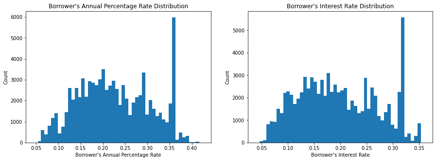

```python
# set figure size
plt.figure(figsize = [15, 5])

# plot first graph
plt.subplot(1, 2, 1)
sb.distplot(
    data['BorrowerAPR'], kde=False, hist_kws = {'alpha' : 1}
)

# assign title and axis labels
plt.title("Borrower's Annual Percentage Rate Distribution")
plt.ylabel('Count')
plt.xlabel("Borrower's Annual Percentage Rate")

# plot second graph
plt.subplot(1, 2, 2)
sb.distplot(
    data['BorrowerRate'], kde=False,hist_kws = {'alpha' : 1}
)

# assign title and axis labels
plt.title("Borrower's Interest Rate Distribution")
plt.ylabel('Count')
plt.xlabel("Borrower's Interest Rate");
```

There are two peaks centered at 0.2 and 0.28, respectively, and a very shaped peak between 0.35 and 0.36. A very small number of loans have an APR higher than 0.4.

Putting both distributions on the same plot will help us appreciate the similarities better.

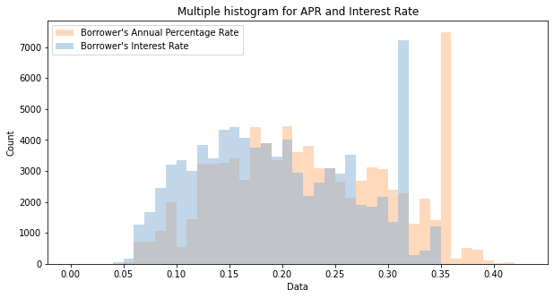

```python
# assign appropriate bin size
bin_size = 0.01
bins = np.arange(0, data['BorrowerAPR'].max() + bin_size, bin_size)

# set the figure size
plt.figure(figsize=(10,5))

# plot first graph
plt.hist(
    data['BorrowerAPR'],
    bins = bins,
    color = "#ffb47b",
    alpha = 0.5,
    label = "Borrower's Annual Percentage Rate",
)

# plot second graph
plt.hist(
    data['BorrowerRate'],
    bins = bins,
    color = "#84b1d4",
    alpha = 0.5,
    label = "Borrower's Interest Rate",
)

# assing title and axis labels
plt.legend()
plt.title("Multiple histogram for APR and Interest Rate")
plt.ylabel('Count')
plt.xticks([0, 0.05, 0.1, 0.15, 0.20, 0.25, 0.30, 0.35, 0.40])
plt.xlabel("Data");
```

Indeed, the interest rate retains the same multi-modal distribution with slightly lower values.

Now, I will have a look at the borrower's employment status.

Are all borrowers employed at the time of loan application ?

```python
# some of these categorical variables can be combined into a single one.
employment_status_data = data['EmploymentStatus'].copy()
employment_status_data.replace(
    {
        'Full-time': 'Employed',
        'Self-employed': 'Employed',
        'Part-time': 'Employed',
        'Not available': 'Other'
    },
    inplace = True
)
```

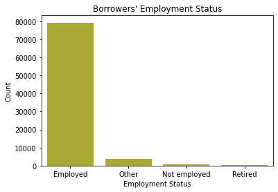

```python
# get the total counts of the various employment status
employment_status_count = employment_status_data.value_counts()

# plot the graph
sb.countplot(
    x = employment_status_data,
    order = employment_status_count.index,
    color = sb.color_palette()[8]
)

# assign title and axis labels
plt.title("Borrowers' Employment Status")
plt.ylabel('Count')
plt.xlabel('Employment Status');
```

According to the plot above, the majority of borrowers who apply for loans are already working; just a small percentage are unemployed or retired at the time of application.

The annual income range and the claimed monthly income are two more pertinent factors pertaining to the borrower's employment that I will examine next.

```python
# Gets the unique income ranges of borrowers
data['IncomeRange'].unique()
```

```
array(['$50,000-74,999', '$25,000-49,999', '$100,000+', '$75,000-99,999',
       '$1-24,999', 'Not employed', '$0'], dtype=object)
```

```python
# some of these values can be combined into a single value.
income_range_data = data['IncomeRange'].copy()

income_range_data.replace(
    ['Not employed'],
    '$0',
    inplace = True
)
```

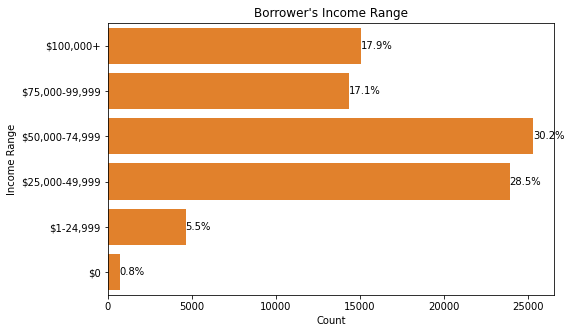

```python
# sum of counts in each income group
income_range_count = income_range_data.value_counts()

# get the unique values in the decreasing order of the frequency
income_range_order = income_range_count.index

# returns the sum
total_income = income_range_count.sum()

order = [
    '$100,000+',
    '$75,000-99,999',
    '$50,000-74,999',
    '$25,000-49,999',
    '$1-24,999',
    '$0'
]

# set figure size
plt.figure(figsize = (8,5))

# plot the graph
sb.countplot(
    y = income_range_data,
    order = order,
    color = sb.color_palette()[1]
)
plt.title("Borrower's Income Range")
plt.ylabel('Income Range')
plt.xlabel('Count')

for i in range (len(order)):
    value = order[i]
    count = income_range_count[value]
    # convert count into a percentage, and then into string
    pct_string = '{:0.1f}'.format(100 * count / total_income) + '%'
    # print the string value on the bar.
    plt.text(count + 1, i, pct_string, va = 'center')
```

According to the plot above, majority of borrowers have an annual income range between 25,000 dollars and 74,999 dollars per year. This constitutes a percentage of 58.7% of the total borrowers. Comparing this percentage to the total number of borrowers who are employed examined above, does this communicate that all borrowers who fall within this income range are enployed? This will be examined further in the bivarite analysis section.

Does majority of borrowers have their stated monthly income above 2,000 dollars ?

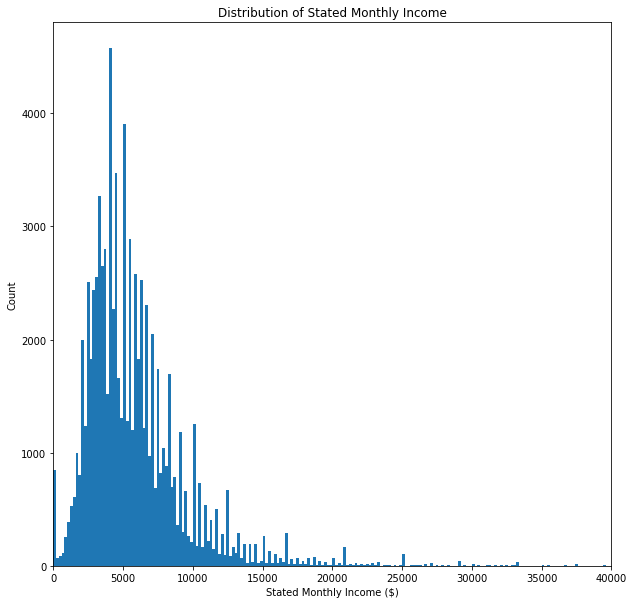

```python
# Set the figure size
plt.figure(figsize = [10, 10])

# Set the bin size
bin_size = 200
bins = np.arange(0, data['StatedMonthlyIncome'].max() + bin_size, bin_size)

# Plot the graph
plt.hist(
    data = data,
    x = 'StatedMonthlyIncome',
    bins = bins
)

# zoom in the plot to make it clear
plt.xlim(0, 40000)

# assign title and axis labels
plt.title('Distribution of Stated Monthly Income')
plt.ylabel('Count')
plt.xlabel('Stated Monthly Income ($)');
```

The histogram shows an unimodal right-skewed distribution of the data.

The majority of borrowers are in the range of monthly incomes from approximately 2,000 dollars to 8,000 dollars per month.

Looking at the distribution of the plot above, i would like to examine any potential outliers.

I will utilize the Inter Quartile Range formula for this since the data is not normally distributed.

```python
# define a function to find all outliers
def find_outliers_IQR(df):

   q1=df.quantile(0.25)

   q3=df.quantile(0.75)

   IQR=q3-q1

   outliers = df[((df<(q1-1.5*IQR)) | (df>(q3+1.5*IQR)))]

   return outliers
```

```python
# get the number of outliers
outliers = find_outliers_IQR(data['StatedMonthlyIncome'])

print('number of outliers: ' + str(len(outliers)))

# the maximum value
print('max outlier value: ' + str(outliers.max()))

# the minimum value
print('min outlier value: '+ str(outliers.min()))
```

```
number of outliers: 3888
max outlier value: 1750002.916667
min outlier value: 12577.333333
```

It is worth looking at the percentage of the data that constitute the outliers

```python
print('{:0.2f}%'.format(len(outliers) / data.shape[0] * 100))
```

```
4.63%
```

```python
# Query all the outliers
data.query('StatedMonthlyIncome.isin(@outliers).values')
```

|  | ListingKey | LoanOriginalAmount | Term | BorrowerAPR | BorrowerRate | ProsperRating | EstimatedReturn | MonthlyLoanPayment | EmploymentStatus | IncomeRange | StatedMonthlyIncome | LoanStatus | ListingCategory |
| --- | --- | --- | --- | --- | --- | --- | --- | --- | --- | --- | --- | --- | --- |
| 33 | 0F6B3496936961316AEE1B2 | 16000 | 36 | 0.08191 | 0.0785 | AA | 0.05550 | 500.28 | Employed | $100,000+ | 13083.333333 | Completed | 7 |
| 40 | 10A43601079743929992413 | 15000 | 60 | 0.19630 | 0.1725 | C | 0.07923 | 374.81 | Self-employed | $100,000+ | 12750.000000 | Current | 1 |
| 45 | 0F843574249889932A8662E | 25000 | 60 | 0.13227 | 0.1099 | A | 0.06660 | 543.44 | Employed | $100,000+ | 16000.000000 | Current | 1 |
| 48 | 0F923587782964897A58B1B | 15000 | 60 | 0.17522 | 0.1519 | B | 0.08760 | 358.35 | Employed | $100,000+ | 14583.333333 | Current | 1 |
| 95 | 0FFC3601335963354A35791 | 20000 | 36 | 0.12691 | 0.0990 | A | 0.05879 | 644.41 | Employed | $100,000+ | 14833.333333 | Current | 1 |
| 102 | 0F823461624751165710F76 | 10000 | 36 | 0.15529 | 0.1338 | A | 0.10240 | 322.34 | Full-time | $100,000+ | 15000.000000 | Completed | 1 |
| 196 | 10B03560492883055C87101 | 25000 | 60 | 0.15752 | 0.1346 | A | 0.09060 | 574.73 | Employed | $100,000+ | 33333.333333 | Current | 19 |
| 205 | 2EB43599416431334B2A6D6 | 10000 | 36 | 0.07922 | 0.0659 | AA | 0.04261 | 306.90 | Employed | $100,000+ | 13750.000000 | Current | 1 |
| 208 | 2ECD354707259234475F078 | 15000 | 60 | 0.23318 | 0.2085 | B | 0.13850 | 404.54 | Employed | $100,000+ | 17500.000000 | Current | 1 |
| 224 | 2F293599751524472C82DEA | 30000 | 36 | 0.13799 | 0.1099 | A | 0.06388 | 982.02 | Employed | $100,000+ | 33333.333333 | Current | 1 |
| 291 | 306936024573363075E56A0 | 15000 | 60 | 0.15868 | 0.1355 | B | 0.07192 | 345.53 | Self-employed | $100,000+ | 25000.000000 | Current | 1 |
| 307 | 08EE35956672069418D878A | 15000 | 36 | 0.15223 | 0.1239 | A | 0.06910 | 501.01 | Self-employed | $100,000+ | 40000.000000 | Current | 1 |
| 313 | 09233589620788733CFB8CE | 15000 | 36 | 0.19144 | 0.1550 | B | 0.08215 | 523.66 | Self-employed | $100,000+ | 13333.333333 | Current | 1 |
| 334 | 00A93571705469822AF1B6E | 12000 | 36 | 0.21025 | 0.1734 | C | 0.09120 | 429.87 | Employed | $100,000+ | 27500.000000 | Current | 2 |
| 353 | 094D3534821837880D65EB9 | 2000 | 12 | 0.28918 | 0.1900 | D | 0.06880 | 184.31 | Employed | $100,000+ | 15000.000000 | Completed | 7 |
| 393 | 411D3488346878909FEF3B2 | 4700 | 36 | 0.11296 | 0.0920 | A | 0.06080 | 149.90 | Full-time | $100,000+ | 16666.666667 | Completed | 1 |
| 434 | 01043580087553342D9A449 | 3500 | 60 | 0.10878 | 0.0869 | AA | 0.05520 | 72.13 | Employed | $100,000+ | 14166.666667 | Current | 6 |
| 442 | 09AD35918712001025AC1BD | 5000 | 36 | 0.20524 | 0.1685 | C | 0.07824 | 177.89 | Employed | $100,000+ | 12916.666667 | Current | 1 |
| 476 | 00EC3604528464581EB9190 | 15000 | 60 | 0.14528 | 0.1224 | B | 0.06491 | 335.49 | Employed | $100,000+ | 13083.333333 | Current | 1 |
| 479 | 010235774885928177EC84F | 18000 | 36 | 0.23530 | 0.1979 | C | 0.09750 | 667.02 | Employed | $100,000+ | 14625.000000 | Current | 1 |
| 496 | 450F3573988257953846D1B | 3000 | 36 | 0.30285 | 0.2639 | E | 0.10930 | 121.50 | Employed | $100,000+ | 17500.000000 | Current | 1 |
| 513 | 009D3584881012181C31459 | 8000 | 36 | 0.27285 | 0.2346 | D | 0.10390 | 311.60 | Employed | $100,000+ | 17500.000000 | Current | 1 |
| 540 | 454F359502858630924B82C | 15000 | 36 | 0.20984 | 0.1730 | C | 0.08524 | 537.03 | Self-employed | $100,000+ | 18333.333333 | Current | 14 |
| 554 | 091B3596837609725239239 | 20000 | 60 | 0.09367 | 0.0809 | AA | 0.04929 | 406.39 | Employed | $100,000+ | 15000.000000 | Current | 7 |
| 611 | 00DB355736392162679A768 | 25000 | 60 | 0.17317 | 0.1499 | A | 0.09970 | 594.62 | Employed | $100,000+ | 26666.666667 | Current | 1 |
| 613 | 00F13534158626187686B3B | 20500 | 36 | 0.12528 | 0.0974 | A | 0.06720 | 658.98 | Employed | $100,000+ | 13333.333333 | Completed | 1 |
| 621 | 2C753603308658449A8BF18 | 15000 | 36 | 0.20051 | 0.1635 | C | 0.07355 | 529.95 | Employed | $100,000+ | 16666.666667 | Current | 1 |
| 633 | 07FB35970598962377DCEA7 | 30000 | 36 | 0.12691 | 0.0990 | A | 0.05879 | 966.61 | Employed | $100,000+ | 15000.000000 | Current | 1 |
| 637 | 082935799639007458EBFA9 | 35000 | 36 | 0.19236 | 0.1559 | B | 0.08580 | 1223.42 | Employed | $100,000+ | 31666.666667 | Current | 2 |
| 640 | 083235967773321272C26B9 | 10000 | 36 | 0.11563 | 0.0879 | A | 0.05342 | 317.02 | Employed | $100,000+ | 14166.666667 | Current | 2 |
| ... | ... | ... | ... | ... | ... | ... | ... | ... | ... | ... | ... | ... | ... |
| 113110 | D02F36036077314852A4A02 | 11500 | 36 | 0.14243 | 0.1139 | A | 0.06499 | 378.62 | Employed | $100,000+ | 13916.666667 | Current | 1 |
| 113167 | D942360184795187092033B | 35000 | 36 | 0.12117 | 0.0930 | A | 0.05568 | 1117.88 | Employed | $100,000+ | 14166.666667 | Current | 18 |
| 113181 | ED9F354997989447619F62D | 4000 | 36 | 0.33973 | 0.2999 | E | 0.12760 | 169.78 | Employed | $100,000+ | 20000.000000 | Past Due (61-90 days) | 1 |
| 113201 | D0C13510081389953E30369 | 17649 | 36 | 0.06327 | 0.0599 | AA | 0.03700 | 536.85 | Employed | $100,000+ | 13333.333333 | Completed | 1 |
| 113234 | D36E35072253079200D9737 | 6000 | 36 | 0.13109 | 0.1099 | B | 0.04880 | 196.40 | Full-time | $100,000+ | 25000.000000 | Completed | 2 |
| 113262 | F0A03553479866487634946 | 15000 | 60 | 0.17184 | 0.1486 | A | 0.10820 | 355.75 | Self-employed | $100,000+ | 15000.000000 | Current | 3 |
| 113270 | D3AF357238727540198D36B | 2000 | 36 | 0.22712 | 0.1899 | C | 0.09550 | 73.30 | Employed | $100,000+ | 394400.000000 | Current | 7 |
| 113279 | DC723597560049182253415 | 15000 | 36 | 0.21342 | 0.1765 | C | 0.08022 | 539.66 | Employed | $100,000+ | 18750.000000 | Current | 1 |
| 113334 | F32E3598562248095D9811B | 20000 | 36 | 0.09434 | 0.0809 | AA | 0.04929 | 627.56 | Employed | $100,000+ | 18333.333333 | Current | 1 |
| 113422 | D6F5358564236959306F397 | 15000 | 36 | 0.22712 | 0.1899 | C | 0.09550 | 549.76 | Employed | $100,000+ | 45833.333333 | Current | 2 |
| 113426 | D70935745396428047C317A | 25000 | 60 | 0.12716 | 0.1049 | A | 0.06450 | 537.22 | Employed | $100,000+ | 13225.000000 | Current | 1 |
| 113461 | E27835322770965555BF0E0 | 10000 | 36 | 0.29510 | 0.2599 | D | 0.13170 | 402.85 | Employed | $100,000+ | 20000.000000 | Chargedoff | 1 |
| 113464 | E28035775136282494C82CA | 25000 | 36 | 0.14857 | 0.1203 | A | 0.07120 | 830.72 | Employed | $100,000+ | 16666.666667 | Current | 1 |
| 113471 | F64E3521775235384194015 | 11304 | 36 | 0.20200 | 0.1799 | B | 0.10740 | 408.61 | Employed | $100,000+ | 25000.000000 | Current | 2 |
| 113475 | F6683575451524685C1A021 | 3500 | 36 | 0.24246 | 0.2049 | C | 0.09840 | 130.95 | Employed | $100,000+ | 20833.333333 | Current | 1 |
| 113483 | DA0D3599616243126AF7E18 | 5000 | 36 | 0.27776 | 0.2394 | D | 0.09211 | 196.01 | Employed | $100,000+ | 17250.000000 | Current | 1 |
| 113561 | CA7735876014181644CEAEB | 14000 | 60 | 0.19681 | 0.1730 | C | 0.08524 | 350.20 | Employed | $100,000+ | 19166.666667 | Current | 1 |
| 113565 | C20635904379549240FC861 | 25000 | 60 | 0.16294 | 0.1399 | B | 0.07890 | 581.58 | Employed | $100,000+ | 13333.333333 | Current | 1 |
| 113570 | C22535966969728572503D2 | 20000 | 36 | 0.09030 | 0.0769 | AA | 0.04806 | 623.87 | Employed | $100,000+ | 12916.666667 | Current | 1 |
| 113643 | E1CD3564233083074307C82 | 15000 | 36 | 0.24758 | 0.2099 | C | 0.10030 | 565.05 | Employed | $100,000+ | 15833.333333 | Current | 15 |
| 113654 | C44935904882628915B8FF3 | 15000 | 36 | 0.13799 | 0.1099 | A | 0.06663 | 491.01 | Self-employed | $100,000+ | 16666.666667 | Current | 1 |
| 113669 | CCBB35389701036500D9887 | 4000 | 36 | 0.35797 | 0.3177 | HR | 0.12460 | 173.71 | Employed | $100,000+ | 19166.666667 | Completed | 1 |
| 113700 | C47435601077859648BA1A6 | 12500 | 36 | 0.27285 | 0.2346 | D | 0.10390 | 486.87 | Employed | $100,000+ | 14000.000000 | Past Due (1-15 days) | 1 |
| 113749 | C4DA353423976554170D11C | 3500 | 36 | 0.19108 | 0.1621 | B | 0.09000 | 123.41 | Employed | $100,000+ | 12750.000000 | Current | 7 |
| 113776 | C6C335468841634186505C0 | 3000 | 12 | 0.09986 | 0.0628 | A | 0.03280 | 258.59 | Employed | $100,000+ | 23750.000000 | Completed | 1 |
| 113792 | E43C3548328183436FD70FD | 8000 | 36 | 0.26681 | 0.2287 | D | 0.11440 | 309.14 | Self-employed | $100,000+ | 20000.000000 | Completed | 1 |
| 113829 | E49335499832619696CE426 | 5000 | 12 | 0.23554 | 0.1576 | C | 0.05630 | 453.09 | Employed | $100,000+ | 15000.000000 | Completed | 13 |
| 113865 | C9553549830442812C1496F | 9500 | 60 | 0.27462 | 0.2489 | C | 0.14420 | 278.23 | Employed | $100,000+ | 13333.333333 | Completed | 13 |
| 113866 | C9563467992330262C23724 | 3500 | 36 | 0.20504 | 0.1829 | HR | -0.18160 | 127.04 | Self-employed | $100,000+ | 14833.333333 | Completed | 3 |
| 113910 | C9873600264828351437CAB | 4000 | 36 | 0.32446 | 0.2850 | E | 0.10256 | 166.54 | Employed | $100,000+ | 18756.000000 | Current | 1 |

3888 rows × 13 columns

```python
# Drop all outliers from the dataset
data.drop(data.query('StatedMonthlyIncome.isin(@outliers).values').index, inplace=True)
```

Replotting the Stated Monthly Income Distribution

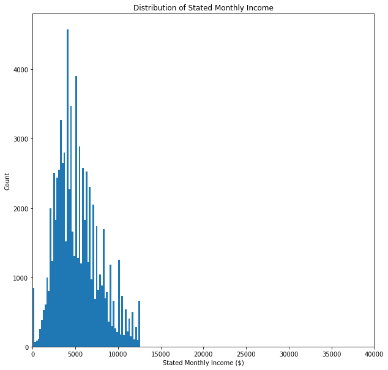

```python
# Set the figure Size
plt.figure(figsize = [10, 10])

# Set the bin size
bin_size = 200
bins = np.arange(0, data['StatedMonthlyIncome'].max() + bin_size, bin_size)

# Plot the graph
plt.hist(
    data = data,
    x = 'StatedMonthlyIncome',
    bins = bins
)

# zoom in the plot to make it clear
plt.xlim(0, 40000)

# assign title and axis labels
plt.title('Distribution of Stated Monthly Income')
plt.ylabel('Count')
plt.xlabel('Stated Monthly Income ($)');
```

Indeed the above plot concludes that, the distribution is skewed to the right and majority of borrowers are in the range of monthly incomes from approximately 2,000 dollars to 8,000 dollars per month.

Next in my analysis, i will be looking at the distribution of the Loan Original Amount Variable

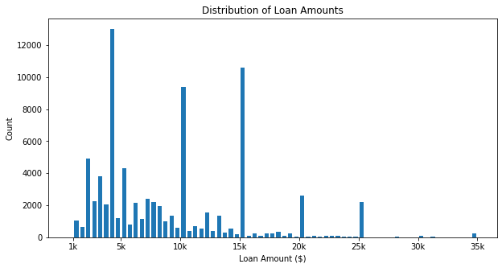

```python
# Set the bin size
bin_size = 500
bins = np.arange(500, data['LoanOriginalAmount'].max() + bin_size, bin_size)

# Set the Figure size
plt.figure(figsize = (10, 5))

# Plot the graph
plt.hist(
    data = data,
    x = 'LoanOriginalAmount',
    bins = bins,
    rwidth = 0.7
)

# assign title and axis labels
plt.title("Distribution of Loan Amounts")
plt.ylabel('Count')
plt.xlabel('Loan Amount ($)')
plt.xticks(
    [1e3, 5e3, 10e3, 15e3, 20e3, 25e3, 30e3, 35e3],
    ['1k', '5k', '10k', '15k', '20k', '25k', '30k', '35k']
);
```

There are extremely few loans between 30,000 dollars and 35,000 dollars, with the majority of loans being in the range of 4,000 dollars, 10,000 dollars, 15,000 dollars, 20,000 dollars, and 25,000 dollars.

To finish examining the variables of interest, i will investigate the distribution of loan status. Are more loans being actively repaid and also how many percentage constitute loans which are defaulted ?

```python
# number of days the payment is due is combined to Past Due
loan_status_data = data['LoanStatus'].copy()

loan_status_data.replace(
    [
        'Past Due (1-15 days)',
        'Past Due (31-60 days)',
        'Past Due (61-90 days)',
        'Past Due (91-120 days)',
        'Past Due (16-30 days)',
        'Past Due (>120 days)'
    ],
    'Past Due',
    inplace = True
)
```

```python
loan_status_data.value_counts()
```

```
Current                   52886
Completed                 18838
Chargedoff                 5211
Past Due                   1976
Defaulted                   995
FinalPaymentInProgress      188
Name: LoanStatus, dtype: int64
```

```python
# get counts of the respective categories
loan_status_count = loan_status_data.value_counts()

loan_status_order = loan_status_count.index

total_loan = loan_status_count.sum()
```

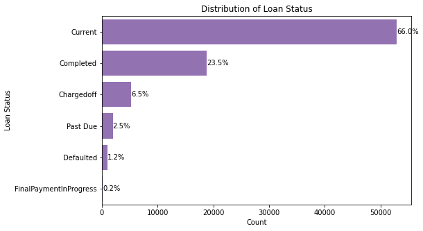

```python
# set the figure size
plt.figure(figsize = (8,5))

# plot the graph
sb.countplot(
    y = loan_status_data,
    order = loan_status_order,
    color = sb.color_palette()[4]
)

#assign title and axis labels
plt.title('Distribution of Loan Status')
plt.ylabel('Loan Status')
plt.xlabel('Count')


# calculate the relative frequency
for i in range (loan_status_count.shape[0]):
    count = loan_status_count[i]
    # convert count into a percentage, and then into string
    pct_string = '{:0.1f}'.format(100 * count / total_loan) + '%'
    # print the string value on the bar
    plt.text(count + 5, i, pct_string, va = 'center')
```

Analyzing the Prosper Ratings

Prosper Ratings allows potential investors to easily consider a loan application’s level of risk since it represents an estimated average annual loss rate range for an investor assigned between AA – HR.

The Prosper Rating is calculated using the borrowers credit score (CreditGrade), obtained from an official reporting agency and the Prosper Score based on the prosper population to get the Annual Loss Rate.

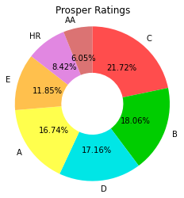

```python
# gets the counts of individual ratings
prosper_rating_count = data['ProsperRating'].value_counts()

# plot a pie chart to represent the data
plt.pie(
    prosper_rating_count,
    labels = prosper_rating_count.index,
    startangle = 90,
    counterclock = False,
    wedgeprops = {'width' : 0.6},
    colors = ['#ff4d4d', '#00cd00','#00e6e6','#ffff4d','#ffc04d', '#e187e1', '#db7373'],
    autopct = '%1.2f%%'
);

# assign title and axis labels
plt.axis('square')
plt.title('Prosper Ratings');
```

Estimated Return

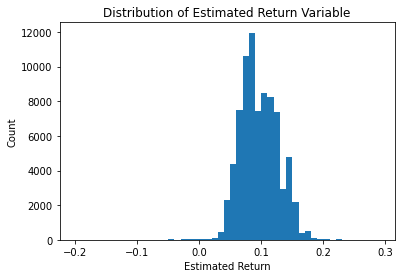

```python
# Assign appropriate bin size
bin_size = 0.01
bins = np.arange(-0.2, data.EstimatedReturn.max() + bin_size, bin_size)

#plot the graph
plt.hist(
    data = data,
    x = 'EstimatedReturn',
    bins = bins
)
# Add title and axis labels
plt.title('Distribution of Estimated Return Variable')
plt.ylabel('Count')
plt.xlabel('Estimated Return');
```

The estimated return has a distribution which is positively skewed to the left with a peak centered at 0.08.

What are the top 3 categories that a borrower is likely to select during loan application? and can this variable give us a clue about the differences in loan amount.

I will use the Listing Category variable to answer this question.

```python
# category listing:
category_dict = {
    0: 'Not Available',
    1: 'Debt Consolidation',
    2: 'Home Improvement',
    3: 'Business',
    4: 'Personal Loan',
    5: 'Student Use',
    6: 'Auto',
    7: 'Other',
    8: 'Baby&Adoption',
    9: 'Boat',
    10: 'Cosmetic Procedure',
    11: 'Engagement Ring',
    12: 'Green Loans',
    13: 'Household Expenses',
    14: 'Large Purchases',
    15: 'Medical/Dental',
    16: 'Motorcycle',
    17: 'RV',
    18: 'Taxes',
    19: 'Vacation',
    20: 'Wedding Loans'
}
```

```python
# replace the numerical values by the corresponding category
data['ListingCategory'].replace(
    category_dict.keys(),
    category_dict.values(),
    inplace = True
)
```

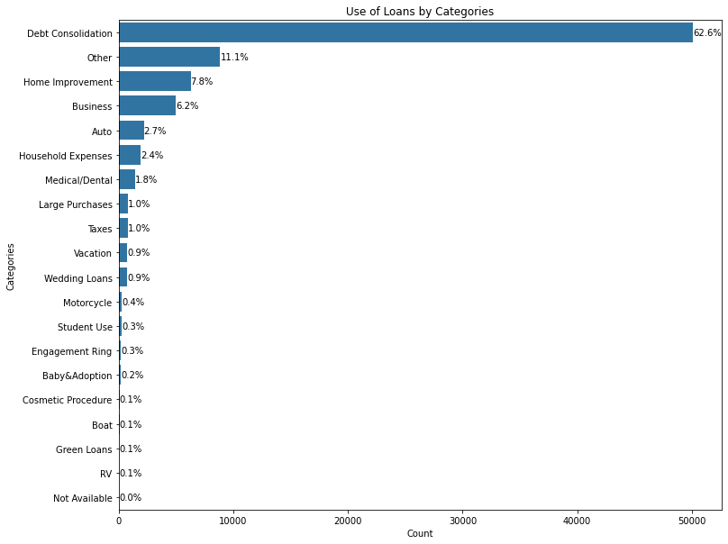

```python
# get series containing counts of unique values in descending order
listing_category_counts = data['ListingCategory'].value_counts()

# get the unique values in the decreasing order of the frequency
listing_category_order = listing_category_counts.index

# returns the sum of all not-null values
n_listing_category = listing_category_counts.sum()

# set the figure size
plt.figure(figsize = (12, 10))

# plot the graph
sb.countplot(
    data = data,
    y = 'ListingCategory',
    order = listing_category_order,
    color = sb.color_palette()[0]
)

# assign title and axis labels
plt.title('Use of Loans by Categories')
plt.ylabel('Categories')
plt.xlabel('Count');

for i in range (listing_category_counts.shape[0]):
    count = listing_category_counts[i]
    # convert count into a percentage, and then into string
    pct_string = '{:0.1f}'.format(100 * count / n_listing_category) + '%'
    # print the string value on the bar
    plt.text(count + 1, i, pct_string, va = 'center')
```

The statistics demonstrate that this variable is not substantial enough to establish differences in the loan amount.

### Discuss the distribution(s) of your variable(s) of interest. Were there any unusual points? Did you need to perform any transformations?

The annual percentage rate (APR) distribution for the loan appears to be multimodal. There are multiple peaks for the loan's initial amount, with the highest ones occurring at 4,000, 10,000, 15,000, 20,000, and 25,000 dollars.

The stated monthly income variable contained unusual points which constitutes outliers that were removed. None of the variables exmained was transformed.

### Of the features you investigated, were there any unusual distributions? Did you perform any operations on the data to tidy, adjust, or change the form of the data? If so, why did you do this?

Categorical types have been applied to some column values. For the 'LoanStatus' column, the 'Pas Due' type categories have been merged into one, since it is not a value of interest for the investigation. The same goes for some categories in the "IncomeRange" and "EmploymentStatus" columns.

There were several outlier points found when looking into stated monthly income variable. Since outliers can greatly impact analysis and conclusions drawn from a plot, all such points were removed from the dataset.

## Bivariate Exploration

This section will start off by examining the correlations between the variables of interest.

```python
# More Numerical Relationships
numerical_vars = [
    'LoanOriginalAmount',
    'BorrowerAPR',
    'BorrowerRate',
    'EstimatedReturn',
    'MonthlyLoanPayment',
    'StatedMonthlyIncome'
]
```

```
loans_samp.shape= (1000, 13)
```

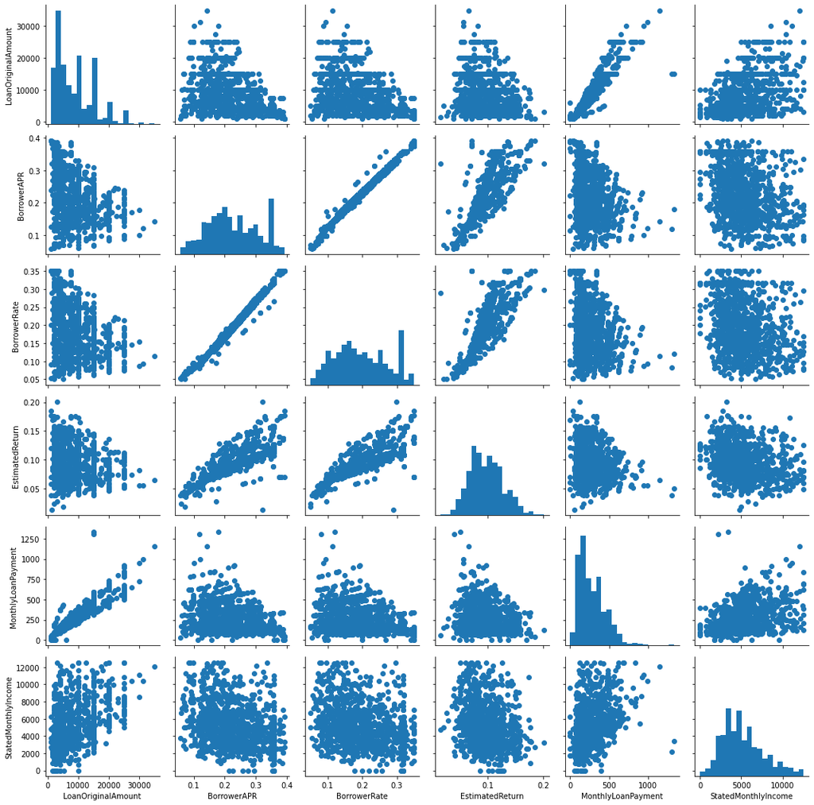

```python
# scatter plot matrix of the variables (1000 samples each)
loans_sample = data.sample(n  = 1000, replace = False)
print("loans_samp.shape=", loans_sample.shape)

g = sb.PairGrid(
    data = loans_sample,
    vars = numerical_vars
)
g = g.map_diag(
    plt.hist,
    bins = 20
)
g.map_offdiag(plt.scatter);
```

However, since the annual percentage rate (BorrowerAPR) and the yearly interest rate (BorrowerRate) have a similar distribution, it is not surprising that the annual percentage rate (BorrowerAPR) is higher than the annual interest rate (BorrowerRate).

The pairwise correlation between the variables

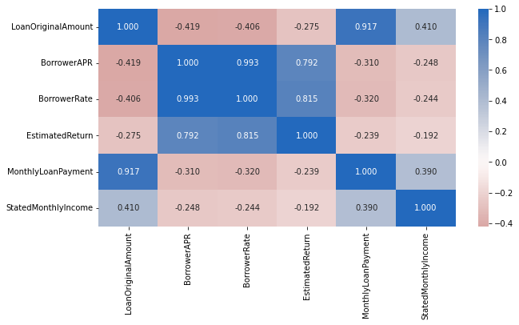

```python
# correlation plot
plt.figure(figsize = [10, 5])

sb.heatmap(
    data[numerical_vars].corr(),
    annot = True,
    fmt = '.3f',
    cmap = 'vlag_r',
    center = 0
);
```

The pairwise correlation plot above reaffirms the conclusions made above. The correlation coefficient between BorrowerAPR and BorrowerRate is 0.993 which implies a highly strong positive correlation meaning that, as BorrowerRate is increasing, BorrowerAPR will also be increasing. Also, the Loan Original Amount has a weak positive correlation with the Stated Monthly Income which implies that though the loaned amount given to a person will be based on Not only his or her monthly stated income but also other factors. Finally, the BorrowerRate is positively correlated with the Estimated Return of a loan.

Examining the relationship between the LoanOriginalAmount vs MonthlyLoanPayment, LoanOriginalAmount vs BorrowerAPR and finally LoanOriginalAmount vs BorrowerRate

```python
# define a function to plot such graphs
def plot_numerical_vars(x, numerical_vars):
    for i in range(len(numerical_vars)):
        var = numerical_vars[i]
        plt.sca(axes[i])
        sb.regplot(
            data = data,
            y = var,
            x = x,
            truncate = False,
            scatter_kws = {'alpha':1/10}
)
```

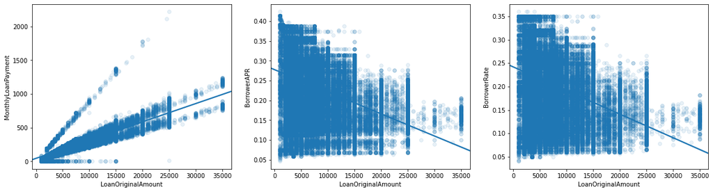

```python
# plot the graphs
fig, axes = plt.subplots(
    nrows = 1,
    ncols = 3,
    figsize = [20,5]
)

plot_numerical_vars(
    'LoanOriginalAmount',
    ['MonthlyLoanPayment', 'BorrowerAPR', 'BorrowerRate']
)
```

Relationship between BorrowerAPR, BorrowerRate and EstimatedReturn

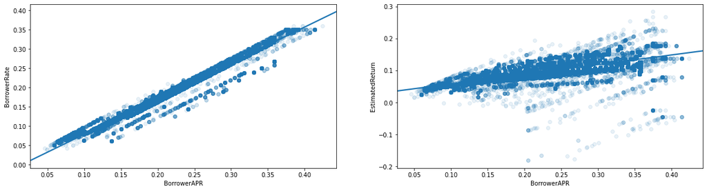

```python
# Plot the graphs
fig, axes = plt.subplots(
    nrows = 1,
    ncols = 2,
    figsize = [20,5]
)

plot_numerical_vars(
    'BorrowerAPR',
    ['BorrowerRate', 'EstimatedReturn']
)
```

The EstimatedReturn has a strong positive relationship with the BorrowerAPR. This implies that, All factors that impacts the Estimated Return of a Loan also impacts the BorrowersAPR.

```python
# function definition to plot box plot
def boxgrid(x, y, **kwargs):
    default_color = sb.color_palette()[0]
    sb.boxplot(
        x = x,
        y = y,
        color = default_color
    )
```

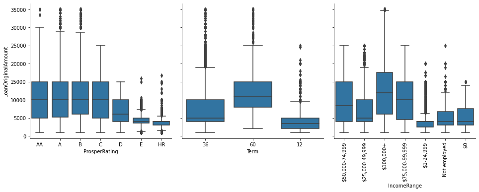

```python
# Ploting the graph
g = sb.PairGrid(
    data = data,
    y_vars = ['LoanOriginalAmount'],
    x_vars = ['ProsperRating', 'Term', 'IncomeRange'],
    height=4.5,
    aspect = 1
)
g.map(boxgrid)
plt.xticks(rotation = 90);
```

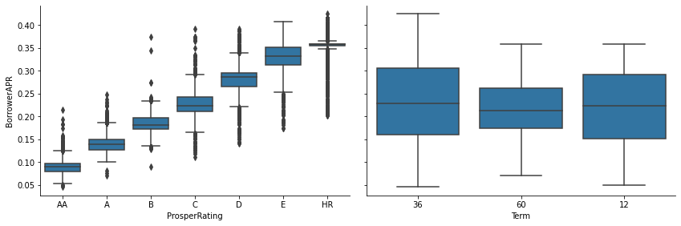

```python
#Plot the graph
g = sb.PairGrid(
    data = data,
    y_vars = ['BorrowerAPR'],
    x_vars = ['ProsperRating', 'Term'],
    height = 4,
    aspect = 1.5
)
g.map(boxgrid);
```

According to the box plot above, there is a very strong positive relationship between the borrower's annual percentage rate (APR) and the Posper rating assigned to the loan. As a result, loans with very low annual loss rates (AA, A, or B) have low APR values, while loans with high risk ratings (D, E, or HR) have high APR values.

The median values for the three potential outcomes are comparable in the second plot's median. The length of the loan and the yearly percentage rate don't follow a straight line.

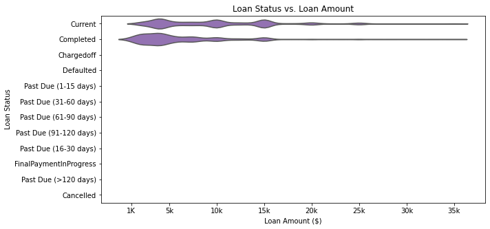

```python
# Get all loans with status of Current or Completed
loan_status_df = data.query('LoanStatus == "Current" | LoanStatus == "Completed"')

# Set the figure size
plt.figure(figsize = (10,5))

# Plot the graph
sb.violinplot(
    data = loan_status_df,
    y = 'LoanStatus',
    x = 'LoanOriginalAmount',
    inner = None,
    color = sb.color_palette()[4]
)

# Assign title and axis labels
plt.title('Loan Status vs. Loan Amount')
plt.ylabel('Loan Status')
plt.xlabel('Loan Amount ($)')
plt.xticks(
    [1e3, 5e3, 10e3, 15e3, 20e3, 25e3, 30e3, 35e3],
    ['1K', '5k', '10k', '15k', '20k', '25k', '30k', '35k']
);
```

The distribution of the points is depicted by the area of each plot. Although the long tail reveals certain outliers, it is clear that completed loans are primarily concentrated in the regions that correlate to lesser sums of money. The distribution of loans with a "current" status is more symmetrical along the x-axis.

The Relationship between Stated Monthly Income and Monthly Loan Payment

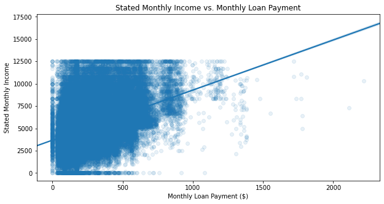

```python
# Set the figure Size
plt.figure(figsize = (10,5))

#plot the graph
sb.regplot(
    data = data,
    y = 'StatedMonthlyIncome',
    x = 'MonthlyLoanPayment',
    truncate = False,
    scatter_kws = {'alpha':1/10}
)

# assign title and axis label
plt.title('Stated Monthly Income vs. Monthly Loan Payment')
plt.ylabel('Stated Monthly Income')
plt.xlabel('Monthly Loan Payment ($)');
```

### Talk about some of the relationships you observed in this part of the investigation. How did the feature(s) of interest vary with other features in the dataset?

From the analysis conducted so far, i can say that:

1. The percentage of debts that are either being paid off now or have previously been repaid is very high, and the status of the remaining loans is extremely little. Loans that have already been repaid typically equate to modest sums of money.
1. The annual percentage rate and interest rate of the borrower are two figures that are directly linked to one another. Prosper uses these figures, together with the expected return, to grade the loan, making it simpler for potential investors to assess the risk of a loan application.
1. With respect to the monthly payment variable, the borrower's monthly income range, and the loan term, the initial loan amount has a positive linear relationship with each of these variables. However, it has a negative correlation with the borrower's interest rate and annual percentage rate.

### Did you observe any interesting relationships between the other features (not the main feature(s) of interest)?

I can say that, expected correlations between the monthly loan payment and the stated monthly income as well as between the company's rating and the estimated return on the loan were discovered.

## Multivariate Exploration

In this section I will explore how the variables that set the annual interest rate of the loan and the estimated return assigned by the company relate to each other to inform potential investors.

I will start by looking at the relationship between the Estimated Return, the Borrowers Interest Rate and the Prosper Rating.

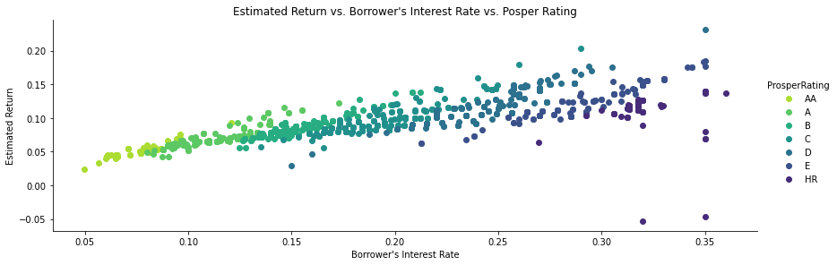

```python
# Randomly Select 1000 samples from each variable
loans_sample = data.sample(n = 1000, replace = False)

# Create a facetGrid plot
g = sb.FacetGrid(
    data = loans_sample,
    hue = 'ProsperRating',
    height = 4,
    aspect = 3,
    palette = 'viridis_r'
)
g.map(
    plt.scatter,
    'BorrowerRate',
    'EstimatedReturn'
)

# Assign Legend, Title and Axis labels
g.add_legend()
plt.title("Estimated Return vs. Borrower's Interest Rate vs. Posper Rating")
plt.ylabel('Estimated Return')
plt.xlabel("Borrower's Interest Rate");
```

This plot shows a clear pattern between the three variables. The estimated return definitely has a positive linear relationship with the borrower's interest rate and Prosper rating.

The relationship between the annual percentage rate (APR) of the borrower and the initial loan amounts for each assigned Prosper Rating

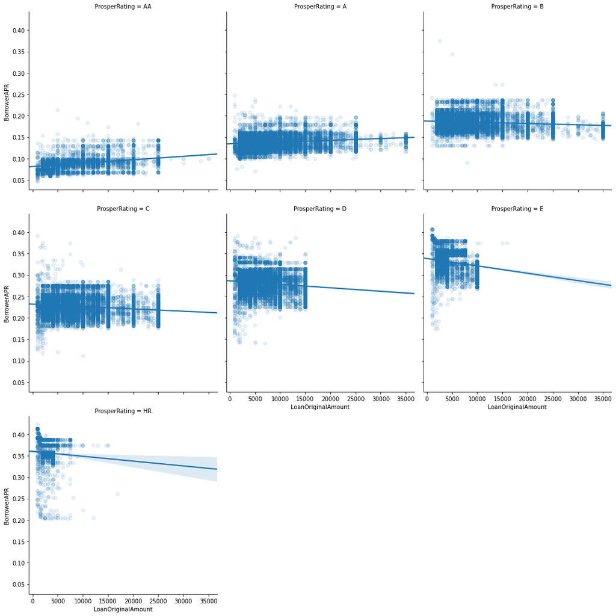

```python
# Ploting the FacetGrid
g = sb.FacetGrid(
    data = data,
    col = 'ProsperRating',
    col_wrap = 3,
    height = 5
)
g.map(
    sb.regplot,
    'LoanOriginalAmount',
    'BorrowerAPR',
    truncate = False,
    scatter_kws = {'alpha':1/10}
);
```

The relationship between the annual percentage rate (APR) of the borrower and the initial loan amounts for each assigned Prosper rating is depicted in the graph above. Surprisingly, the APR value only marginally rises when the loan amount rises for loans with a "AA" and "A" rating. As can be seen above, there is a negative correlation for all other ratings; as the loan amount rises, the Borrowers APR falls.

### Talk about some of the relationships you observed in this part of the investigation. Were there features that strengthened each other in terms of looking at your feature(s) of interest?

This section has reinforced the relationship between the features that set the monthly payment and the total price the borrower will have to pay to complete the loan repayment. The original loan amount is closely related to the APR value and to the Prosper rating. In addition, unusual behaviour has been discovered for ratings with a very small annual loss rate. These ratings, at the same time, also maintain a positive linear relationship with the estimated loan return.

### Were there any interesting or surprising interactions between features?

When the ratings are "A" and "AA," the correlation turns somewhat positive, as seen in the faceted scatterplots.

## Conclusions

The relationships between some of the most crucial factors when applying for a loan have been investigated during the course of this study.

- **What influences the annual percentage rate (APR) or interest rate of the borrower?**

The distribution of both parameters is quite similar, with the tiny exception that the APR figure, which includes fees, is always greater than the interest rate. The dataset contains a number of parameters that are connected to these two values. The initial loan sum is the first factor. There was found a negative relationship between the the Borrower APR and the Original Loan Amount. This implies that the annual percentage rate (APR) for the borrower will be lower as the Loan Amount Increases.

- **What variations exist in loans based on the size of the initial loan amount?**

Loans can be distinguished based on several characteristics rather than the initial loan amount. The term of the loan typically increases proportionately to the loan amount, with larger loans being allowed for 60 months. For this loan, the annual percentage rate (APR) and interest rate for the borrower are inversely related to the loan amount. This implies that interest rates will be higher for smaller loans and vice versa. These two pieces of information are then utilized to determine the monthly payment amount, which likewise rises in proportion to the loan amount. Since the annual income range of the applicant and the initial loan amount are positively correlated, loans are only given to those who can afford them.

```python
from subprocess import call
call(['python', '-m', 'nbconvert', 'Part_I_prosper_loan_exploration.ipynb'])
```